# Tarea 5 2023

Arqueología Cuantitativa

Esteban Arroyo

## Cargamos la base de datos

```r
library(readxl)

base <- read_excel("Base_de_datos_Trabajo_5_TAC_2023.xlsx")
```

## Cargamos las librerías que vamos a usar

```r
library(dplyr)
library(FactoMineR)
library(factoextra)
library(NbClust)
library(ggplot2)
library(janitor)
library(flextable)
library(corrplot)
library(psych)
library(patchwork)
```

### Hacemos un preview de nuestros datos

```r
head(base) %>% flextable() %>% set_caption("Base Base_de_datos_Trabajo_5_TAC_2023.xlsx") %>%
  bg(bg="#0E6655", part = "header") %>% bold(part = "header") %>%
  color(color = "white", part = "header") %>% autofit()
```

Base Base_de_datos_Trabajo_5_TAC_2023.xlsx

| Morfología | Largo Max | Ancho Max | Ancho pedúnculo | Largo pedunculo | Espesor ped |
| --- | --- | --- | --- | --- | --- |
| Lanceolada | 5.1 | 3.3 | 3.3 | 2.1 | 1.07 |
| Lanceolada | 4.2 | 2.3 | 2.2 | 1.6 | 0.74 |
| Lanceolada | 4.4 | 3.1 | 2.5 | 1.8 | 0.78 |
| Lanceolada | 4.4 | 2.7 | 2.2 | 1.9 | 1.09 |
| Pedunculada | 2.5 | 1.6 | 1.1 | 1.3 | 0.59 |
| Pedunculada | 2.4 | 2.0 | 1.2 | 1.2 | 0.72 |

## **Ejercicio 1**

### Explore una clasificación de estas piezas mediante análisis de conglomerados, en base a sus variables métricas. Para lo anterior:

### a) Efectúe análisis jerárquicos mediante los distintos métodos de agrupación vistos en clases, encontrando la mejor clasificación posible

### Primero seleccionamos las columnas que vamos a utilizar

```r
df <- select(base, -Morfología)

head(df) %>% flextable() %>% bg(bg="#0E6655", part = "header") %>%
  bold(part = "header") %>%
  color(color = "white", part = "header") %>% autofit()
```

| Largo Max | Ancho Max | Ancho pedúnculo | Largo pedunculo | Espesor ped |
| --- | --- | --- | --- | --- |
| 5.1 | 3.3 | 3.3 | 2.1 | 1.07 |
| 4.2 | 2.3 | 2.2 | 1.6 | 0.74 |
| 4.4 | 3.1 | 2.5 | 1.8 | 0.78 |
| 4.4 | 2.7 | 2.2 | 1.9 | 1.09 |
| 2.5 | 1.6 | 1.1 | 1.3 | 0.59 |
| 2.4 | 2.0 | 1.2 | 1.2 | 0.72 |

### Creamos la matriz de distancias

```r
mdist <- dist(df,method="euclidean")
```

### Agrupamos con el método de Ward

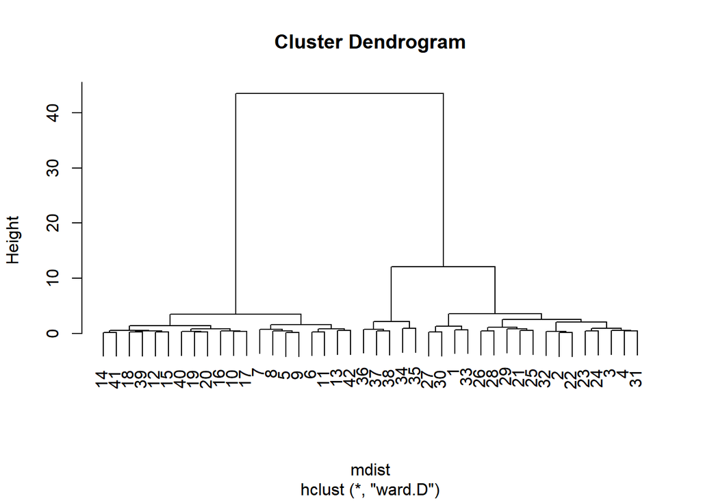

```r
clusterj1 <- hclust(mdist, method = "ward.D")
plot(clusterj1)
```

### Nos orientamos por tres cluster

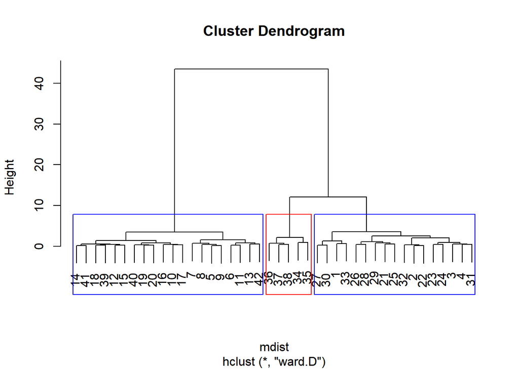

```r
plot(clusterj1)
rect.hclust(clusterj1 , k = 3, border = c("blue","red"))
```

### Otra forma de visualizar el árbol

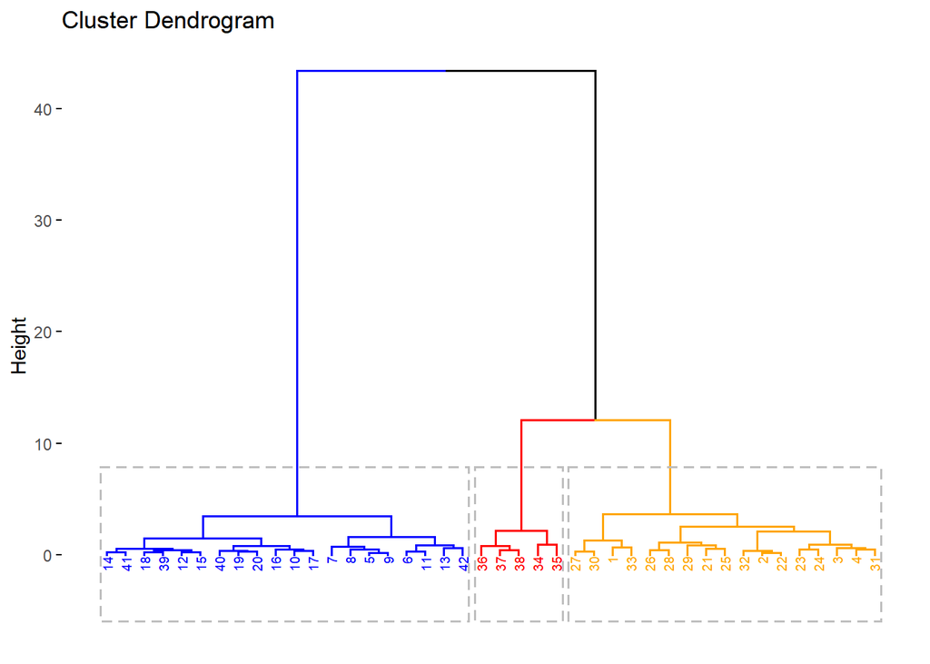

```r
fviz_dend(clusterj1,  k = 3, rect = TRUE, cex = 0.5, k_colors = c("blue","red", "orange")) + guides(scale = "none")
```

### Agrupamos con el metodo método Average Linkage

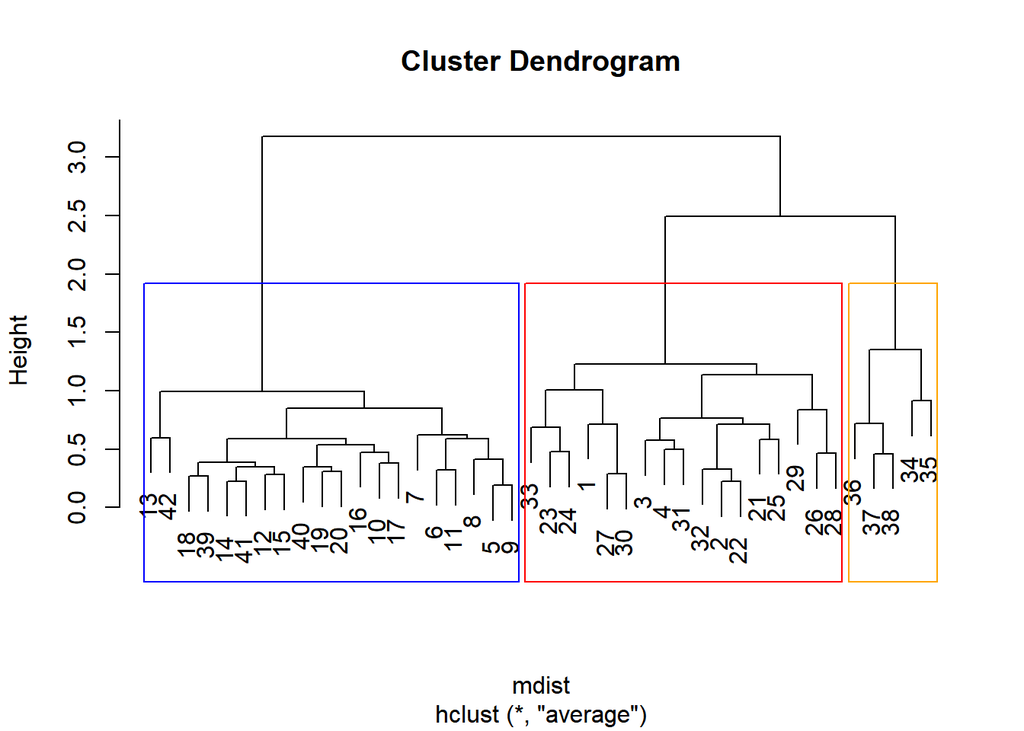

```r
clusterj2 <- hclust(mdist, method = "average")
plot(clusterj2)
rect.hclust(clusterj2 , k = 3, border = c("blue","red", "orange"))
```

### Otra forma de visualizar el árbol

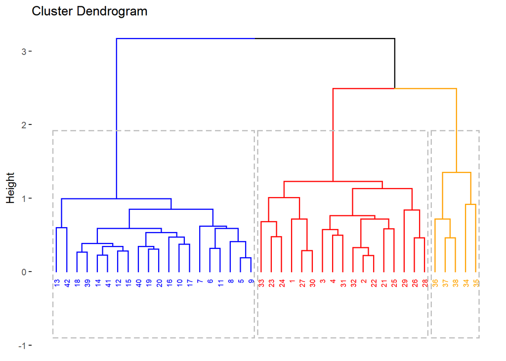

```r
fviz_dend(clusterj2,  k = 3, rect = TRUE, cex = 0.5, k_colors = c("blue","red", "orange")) + guides(scale = "none")
```

### b) Efectúe análisis no jerárquicos para validar la solución y generar los grupos que correspondan

### Realizamos un gráfico de sedimentación para tener idea de cantidad de clusters

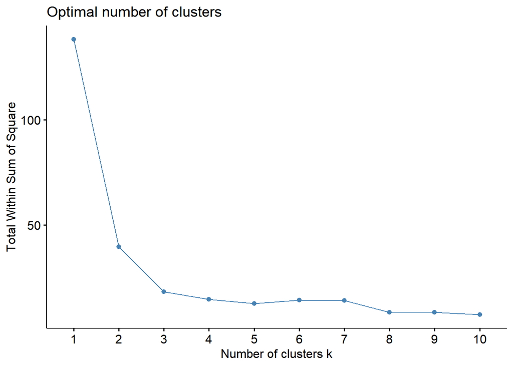

```r
fviz_nbclust(df, kmeans, method = "wss")
```

### Parece que nos podemos quedar con 3 clusters, pero lo vamos a confirmar con el calculo de distintos índices para poder decidir la cantidad final de conglomerados

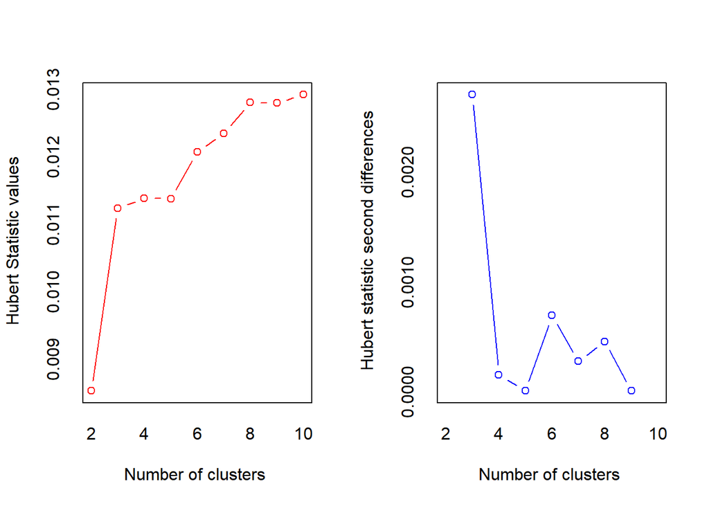

```
*** : The Hubert index is a graphical method of determining the number of clusters.
                In the plot of Hubert index, we seek a significant knee that corresponds to a
                significant increase of the value of the measure i.e the significant peak in Hubert
                index second differences plot.
```

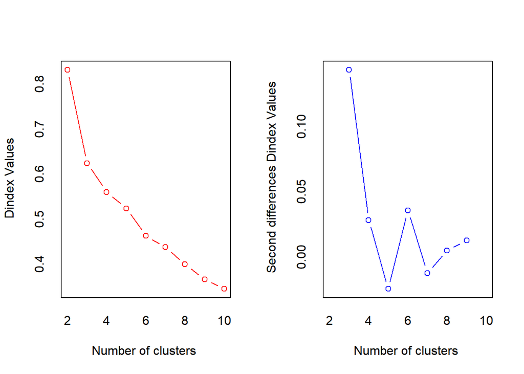

```
*** : The D index is a graphical method of determining the number of clusters.
                In the plot of D index, we seek a significant knee (the significant peak in Dindex
                second differences plot) that corresponds to a significant increase of the value of
                the measure.

* Among all indices:
* 5 proposed 2 as the best number of clusters
* 19 proposed 3 as the best number of clusters
* 1 proposed 8 as the best number of clusters
* 2 proposed 10 as the best number of clusters

                   ***** Conclusion *****

* According to the majority rule, the best number of clusters is  3
```

```r
nclusters <- NbClust(df, distance = "euclidean", min.nc=2, max.nc=10, method = "kmeans", index = "alllong")
```

### Vemos que la mayoría sugiere 3 como el mejor k. Entonces realizamos el k-means

```r
set.seed(20)  #Fijamos una semilla para obtener el mismo resultado
k2 <- kmeans(df, centers = 3, nstart = 42)
k2 %>% as_flextable() %>% theme_zebra()
```

| variable |  | 1 |  | 2 |  | 3 |
| --- | --- | --- | --- | --- | --- | --- |
| withinss |  | 9.9 |  | 5.8 |  | 2.7 |
| size |  | 17 |  | 20 |  | 5 |
| Largo Max* |  | 4.5235 |  | 2.5950 |  | 6.7200 |
| Ancho Max* |  | 2.8235 |  | 1.9600 |  | 3.4800 |
| Ancho pedúnculo* |  | 2.7471 |  | 1.2750 |  | 3.2100 |
| Largo pedunculo* |  | 1.6000 |  | 1.5750 |  | 1.4100 |
| Espesor ped* |  | 0.7976 |  | 0.7585 |  | 0.7480 |

(*) Centers  
Total sum of squares: 138.2  
Total within-cluster sum of squares: 18.4  
Total between-cluster sum of squares: 119.8  
BSS/TSS ratio: 86.7%  
Number of iterations: 2

### visualizamos los resultados del modelo final de k-medias

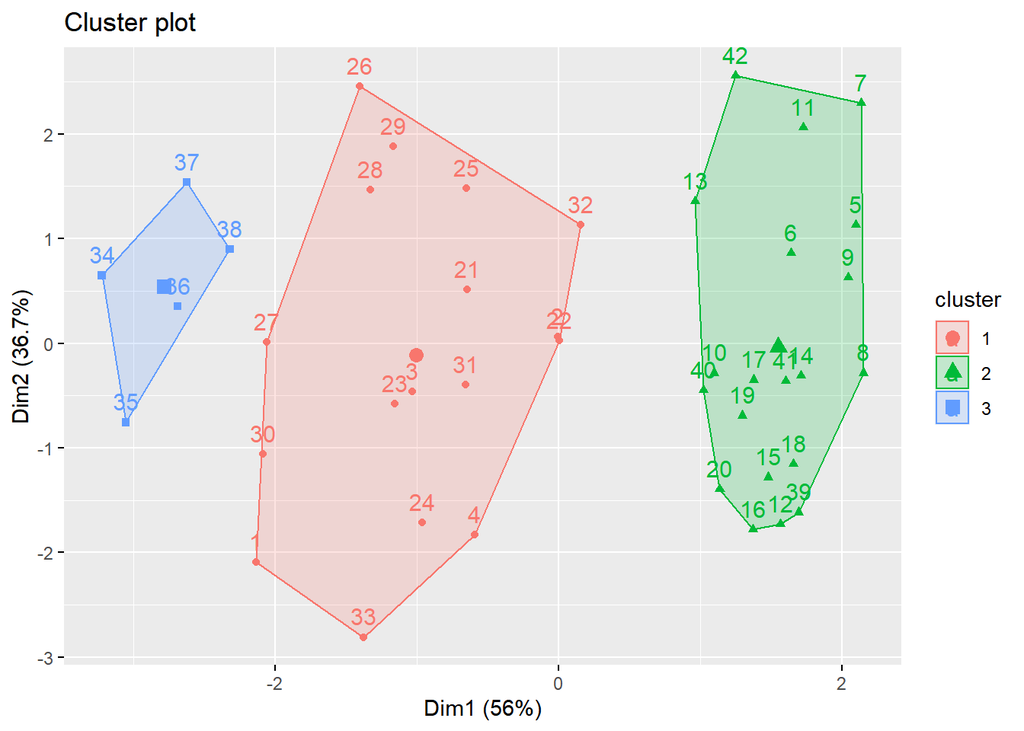

```r
fviz_cluster(k2, data=df)
```

### c) Compare los grupos resultantes, encontrando en qué consisten sus diferencias y qué variables definen las diferencias significativas

### Agregamos las clasificaciones a la Base

```r
cj <- cutree(clusterj1, k = 3)
df$clusterj <- as.factor(cj)
df$clusternj <- as.factor(k2$cluster)
```

### Visualizamos las coincidencias entre ambos clusters

```r
table(df$clusterj, df$clusternj)
```

```
     1  2  3
  1 17  0  0
  2  0 20  0
  3  0  0  5
```

## Observamos que las coindidencias son exactas entre los cluster jerárquicos y los no jerárquicos

### Ahora revisamos una validación interna de los clusters

### Cluster Jerárquico

```r
kruskal.test(`Largo Max`~clusterj,data=df)
```

```
    Kruskal-Wallis rank sum test

data:  Largo Max by clusterj
Kruskal-Wallis chi-squared = 34.002, df = 2, p-value = 4.135e-08
```

```r
kruskal.test(`Ancho Max`~clusterj,data=df)
```

```
    Kruskal-Wallis rank sum test

data:  Ancho Max by clusterj
Kruskal-Wallis chi-squared = 31.752, df = 2, p-value = 1.274e-07
```

```r
kruskal.test(`Ancho pedúnculo`~clusterj,data=df)
```

```
    Kruskal-Wallis rank sum test

data:  Ancho pedúnculo by clusterj
Kruskal-Wallis chi-squared = 32.293, df = 2, p-value = 9.719e-08
```

```r
kruskal.test(`Largo pedunculo`~clusterj,data=df)
```

```
    Kruskal-Wallis rank sum test

data:  Largo pedunculo by clusterj
Kruskal-Wallis chi-squared = 1.5359, df = 2, p-value = 0.464
```

```r
kruskal.test(`Espesor ped`~clusterj,data=df)
```

```
    Kruskal-Wallis rank sum test

data:  Espesor ped by clusterj
Kruskal-Wallis chi-squared = 0.49063, df = 2, p-value = 0.7825
```

### Observamos que Largo pedunculo y Espesor Ped, no tienen diferencias significativas en los cluster jerárquicos

### Cluster No Jerárquico

```r
kruskal.test(`Largo Max`~clusternj,data=df)
```

```
    Kruskal-Wallis rank sum test

data:  Largo Max by clusternj
Kruskal-Wallis chi-squared = 34.002, df = 2, p-value = 4.135e-08
```

```r
kruskal.test(`Ancho Max`~clusternj,data=df)
```

```
    Kruskal-Wallis rank sum test

data:  Ancho Max by clusternj
Kruskal-Wallis chi-squared = 31.752, df = 2, p-value = 1.274e-07
```

```r
kruskal.test(`Ancho pedúnculo`~clusternj,data=df)
```

```
    Kruskal-Wallis rank sum test

data:  Ancho pedúnculo by clusternj
Kruskal-Wallis chi-squared = 32.293, df = 2, p-value = 9.719e-08
```

```r
kruskal.test(`Largo pedunculo`~clusternj,data=df)
```

```
    Kruskal-Wallis rank sum test

data:  Largo pedunculo by clusternj
Kruskal-Wallis chi-squared = 1.5359, df = 2, p-value = 0.464
```

```r
kruskal.test(`Espesor ped`~clusternj,data=df)
```

```
    Kruskal-Wallis rank sum test

data:  Espesor ped by clusternj
Kruskal-Wallis chi-squared = 0.49063, df = 2, p-value = 0.7825
```

### De la misma forma, vemos que Largo pedunculo y Espesor Ped, no tienen diferencias significativas en los cluster no-jerárquicos

### Para los gráficos de dispersión entre pares de variables, usaremos la combinatoria de 5 en 2:

$$\Large C_n^N= \binom{N}{n} = \frac{N!}{n!(N - n)!}$$

### Donde:

### N = 5 (numero de variables)

### n = 2 (grupos de 2 en 2)

### Por tanto hay:

$$\Large \binom{5}{2} = \frac{5!}{2!(5 - 2)!} = \frac{5!}{2!*3!} = 10$$

### 10 combinaciones de variables. En R lo podemos hacer así:

```r
library(gtools)    # Hay que instalar este paquete primero
combinaciones <- combinations(5, 2, c(1:5))

paste("El numero de combinaciones es: ", nrow(combinaciones))
```

```
[1] "El numero de combinaciones es:  10"
```

```r
head(combinaciones, 10)
```

```
      [,1] [,2]
 [1,]    1    2
 [2,]    1    3
 [3,]    1    4
 [4,]    1    5
 [5,]    2    3
 [6,]    2    4
 [7,]    2    5
 [8,]    3    4
 [9,]    3    5
[10,]    4    5
```

### Con el objeto que tiene las combinaciones, podemos usarla para generar todos lo gráficos que necesitemos.

### Graficos de cluster Jérarquico

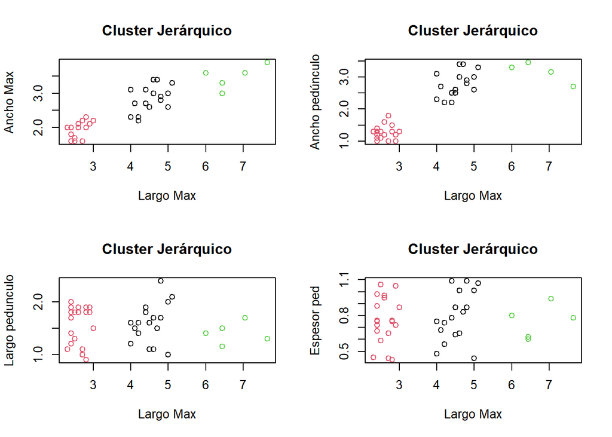

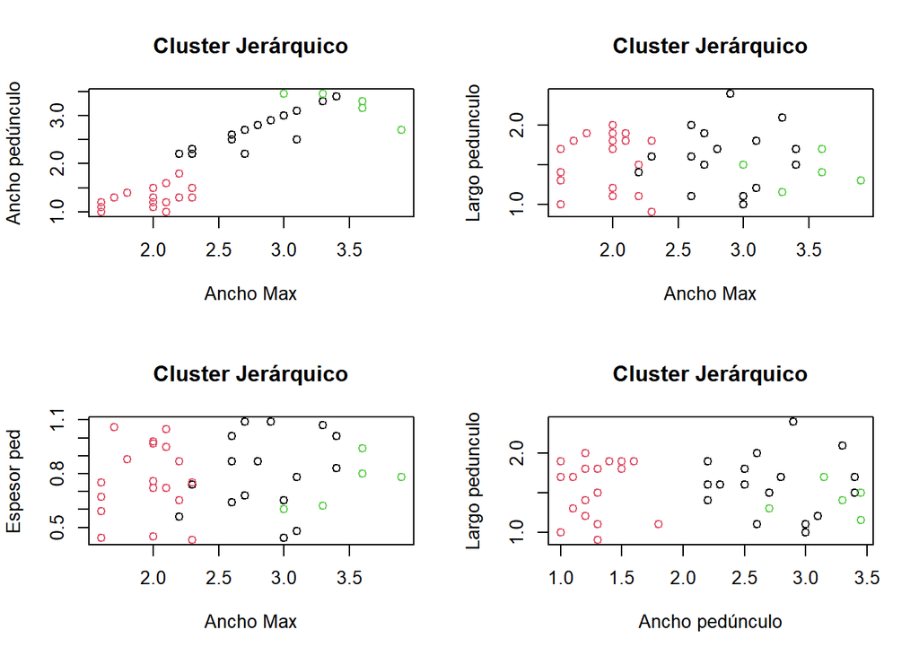

```r
par(mfrow=c(2,2))
for(i in 1:nrow(combinaciones)){
  plot(x = unlist(df[,combinaciones[i,1]]), y = unlist(df[,combinaciones[i,2]]), col= as.factor(df$clusterj), main="Cluster Jerárquico", xlab = names(df[,combinaciones[i,1]]), ylab = names(df[,combinaciones[i,2]]))
  }
```

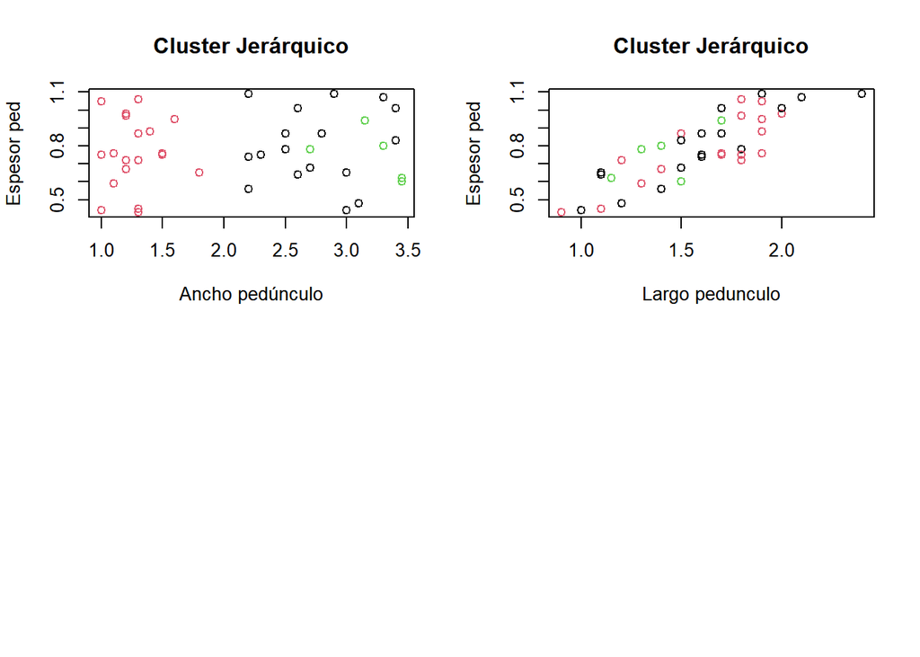

```r
par(mfrow=c(1,1))
```

### Justamente vemos que el Largo pedunculo y Espesor Ped no generan una buena separación entre los clusters

### Graficos de cluster No-Jérarquico

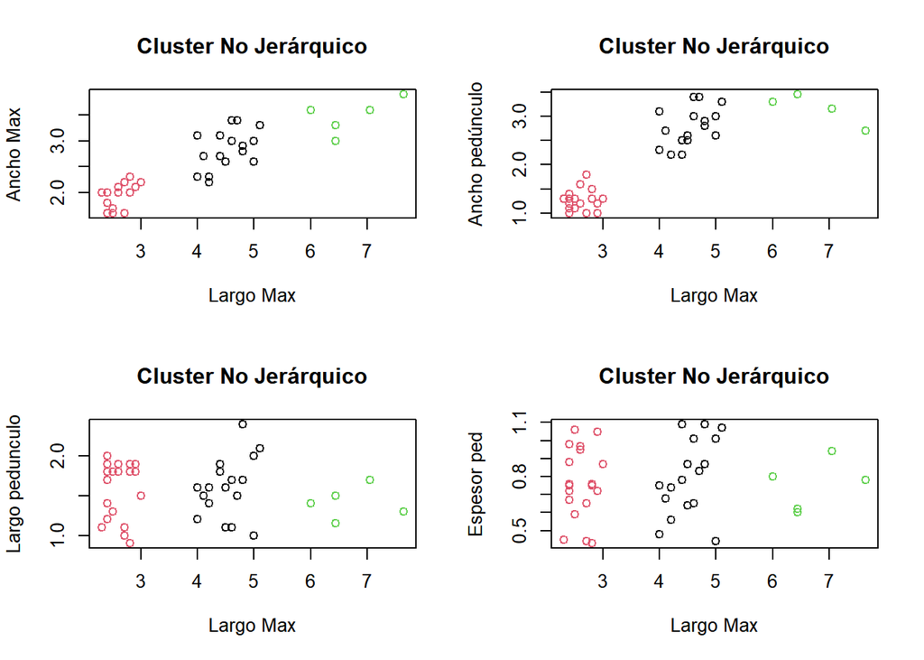

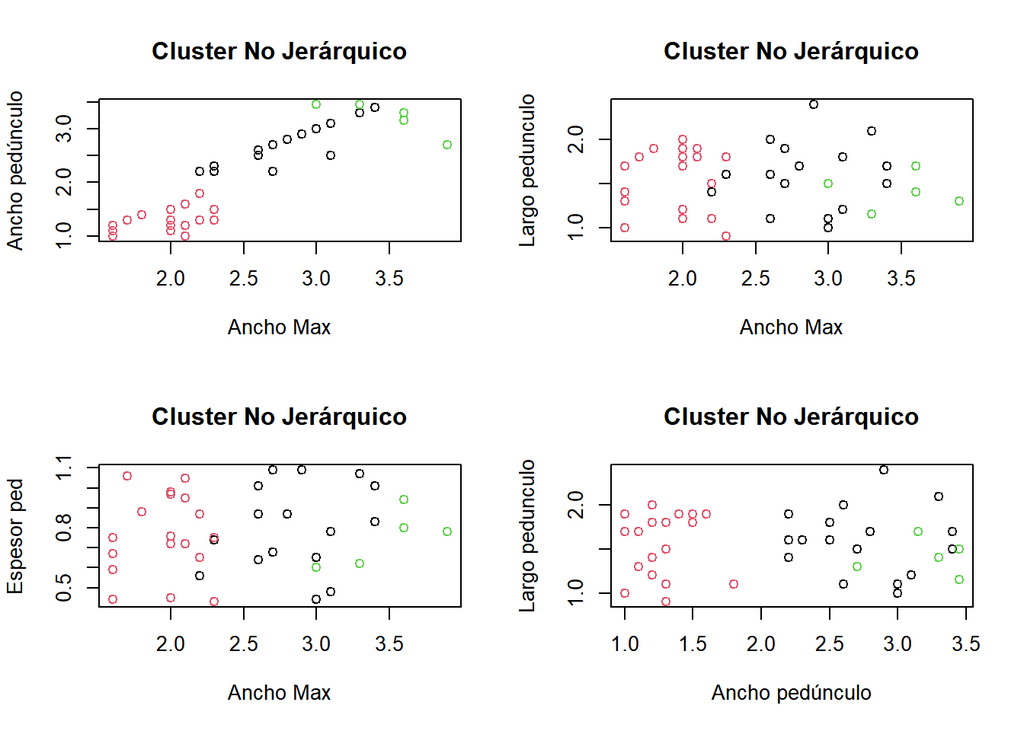

```r
par(mfrow=c(2,2))
for(i in 1:nrow(combinaciones)){
  plot(x = unlist(df[,combinaciones[i,1]]), y = unlist(df[,combinaciones[i,2]]), col= as.factor(df$clusternj), main="Cluster No Jerárquico", xlab = names(df[,combinaciones[i,1]]), ylab = names(df[,combinaciones[i,2]]))
  }
```

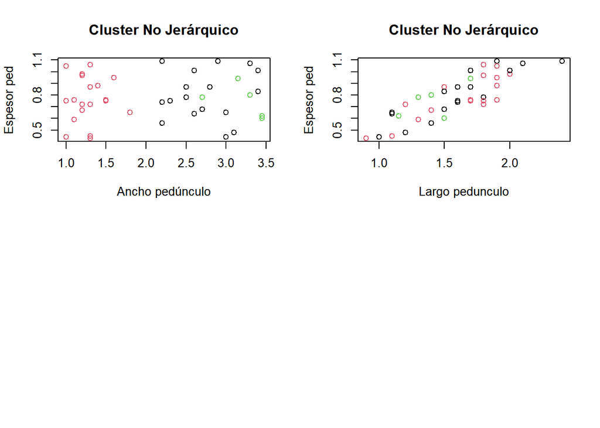

```r
par(mfrow=c(1,1))
```

## 2) Desarrolle un ACP con el fin de reducir las dimensiones que permiten caracterizar a este conjunto de datos. Para lo anterior:

### a) Compruebe los supuestos necesarios para saber si es posible efectuar un ACP válido (continúe con el ejercicio independiente de lo anterior).

### Hacemos una nueva base para eliminar las columnas de los cluster que hicimos previamente

```r
df2 <- df[1:5]
```

### Prueba de correlación

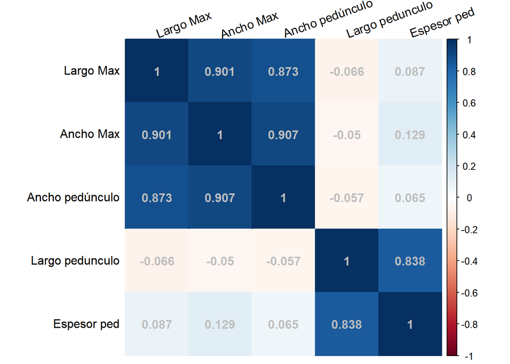

```r
corrplot(cor(df2), method ="color", tl.col = "black", tl.srt = 20, addCoef.col ="grey", number.digits=3, )
```

### Observamos que tenemos correlaciones muy altas entre el Largo Max y Ancho Max con 0.901, el Ancho Max con el Ancho pedúnculo (0.907) y algunas correlaciones bajas entre Ancho Max y Largo pedunculo (-0.05). Esto nos dice que pudieramos considerar eliminar esas variables para que el modelo final sea más robusto. Pero realizaremos otras pruebas para tomar la decisión final.

### Test o Prueba de esfericidad de Barlett

```r
b <- cortest.bartlett(cor(df2), n=42)
bartlett <- data.frame("chisq" = b$chisq, "p.value"=format(b$p.value, scientific = TRUE), "df" = b$df)
bartlett %>% flextable() %>% set_caption("Test de Barlett") %>% theme_zebra() %>% autofit()
```

Test de Barlett

| chisq | p.value | df |
| --- | --- | --- |
| 186.7659 | 9.203688e-35 | 10 |

### Prueba del KMO (Kaiser-Meyer-Olkin)

```r
k <- KMO(df2) #El valor de Overall MSA deveria ser mayor a 0.5 para justificar la realizacion de PCA
Kaiser <- data.frame("MSA"=k$MSA, "Largo Max" = k$MSAi[1], "Ancho Max"= k$MSAi[2], "Ancho pedúnculo" = k$MSAi[3], "Largo pedunculo" = k$MSAi[4], "Espesor ped" = k$MSAi[5])
Kaiser %>% flextable() %>% set_caption("Kaiser-Meyer-Olkin factor adequacy") %>% theme_zebra()
```

Kaiser-Meyer-Olkin factor adequacy

| MSA | Largo.Max | Ancho.Max | Ancho.pedúnculo | Largo.pedunculo | Espesor.ped |
| --- | --- | --- | --- | --- | --- |
| 0.6626861 | 0.8173833 | 0.6984979 | 0.7632857 | 0.4713669 | 0.4673768 |

### Finalmente ambas pruebas no dicen que nuestros datos están aptos para realizar una ACP

### b) Defina un listado de componentes principales, extrayendo de aquellos el número adecuado de componentes para efectuar su análisis (justifique la elección)

```r
ACP <- PCA(df2, ncp=5, graph=FALSE)
as.data.frame(ACP$eig) %>% flextable() %>% set_caption("Autovalores y Varianza Explicada") %>% theme_zebra()
```

Autovalores y Varianza Explicada

| eigenvalue | percentage of variance | cumulative percentage of variance |
| --- | --- | --- |
| 2.8021342 | 56.042685 | 56.04268 |
| 1.8368756 | 36.737512 | 92.78020 |
| 0.1617520 | 3.235041 | 96.01524 |
| 0.1226673 | 2.453347 | 98.46858 |
| 0.0765708 | 1.531416 | 100.00000 |

### Según lo observado, podemos considerar a los dos primeros autovalores que explican el 92% de la varianza o inercia aproximadamente. Lo podemos visualizar de la siguiente forma:

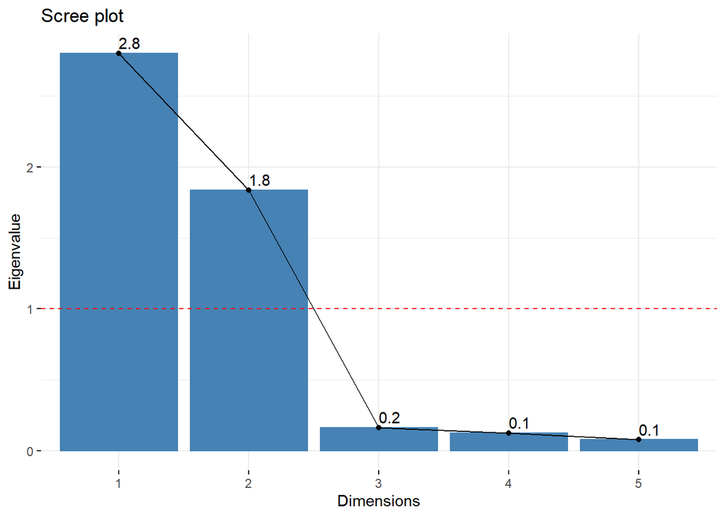

```r
fviz_eig(ACP,choice="eigenvalue", addlabels = TRUE) +
  geom_hline(yintercept=1,linetype="dashed", color = "red")
```

### c) Caracterice los componentes extraídos mediante un gráfico ACP de variables y componentes (gráfico de cargas), sumado a la tabla de cargas factoriales y/o de contribuciones de cada variable a los componentes

### Podemos observar las cargas de las variables en los dos primeros componentes:

```r
cargas <- ACP$var$cor[,1:2]
cargas <- data.frame(cargas)
cargas$var <- rownames(cargas)
cargas%>% flextable(col_keys=c("var", "Dim.1","Dim.2")) %>% set_caption("Cargas en los dos primeros componentes") %>% theme_zebra() %>% autofit()
```

Cargas en los dos primeros componentes

| var | Dim.1 | Dim.2 |
| --- | --- | --- |
| Largo Max | 0.95812436 | -0.04391312 |
| Ancho Max | 0.97195687 | -0.01285745 |
| Ancho pedúnculo | 0.95904151 | -0.05135558 |
| Largo pedunculo | -0.02813774 | 0.96166477 |
| Espesor ped | 0.13740251 | 0.95254680 |

### tambien podemos visulizarlo con la función corrplot

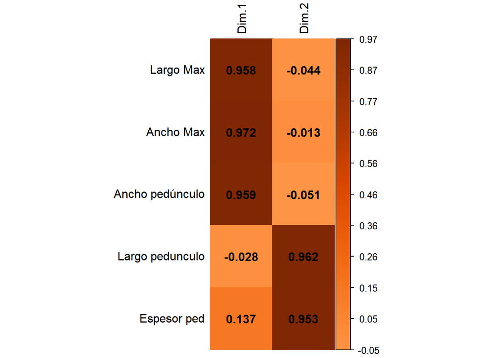

```r
corrplot(ACP$var$cor[,1:2], is.corr = FALSE, method ="color", tl.col = "black", col = COL1("Oranges"), addCoef.col ="black", number.digits=3, cl.ratio = 0.8)
```

### De una forma gráfica podemos visualizar las variables que más contribuyen en la formación de los dos pirmeros componentes

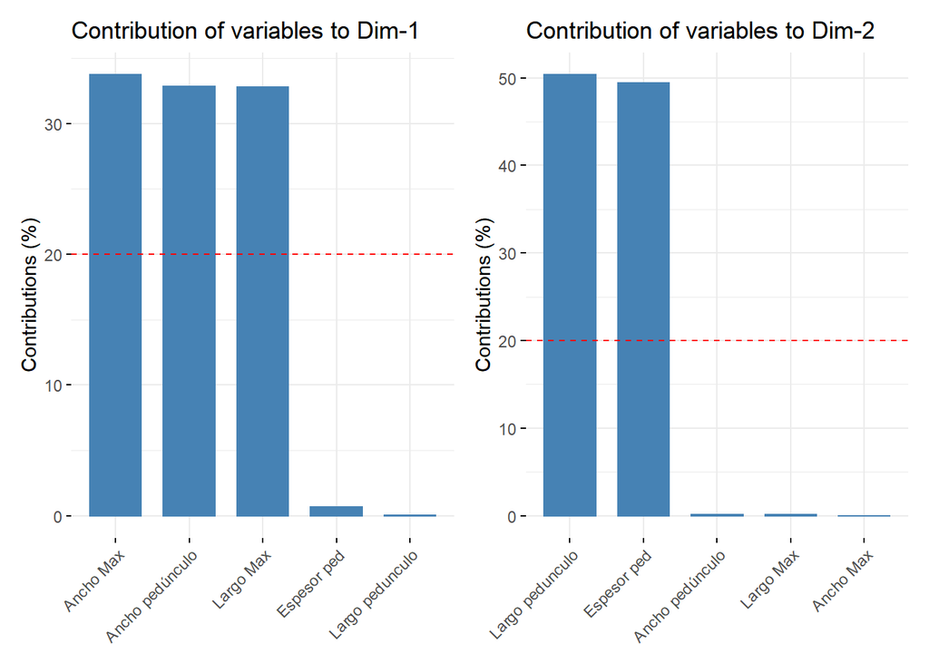

```r
a1 <- fviz_contrib(ACP, choice = "var", axes = 1)
a2 <- fviz_contrib(ACP, choice = "var", axes = 2)
a1 + a2
```

### Observamos que Largo Max, Ancho pedúnculo y Ancho Max son los que más contribuyen en el componente 1, mientras que Largo pedunculo y Espesor ped son los que más contribuyen en el componente 2

### Finalmente, mediante un gráfico de ACP de los dos primeros componentes, podemos visualizar la relación de todas las variables en los dos primeros componenes de forma simultánea

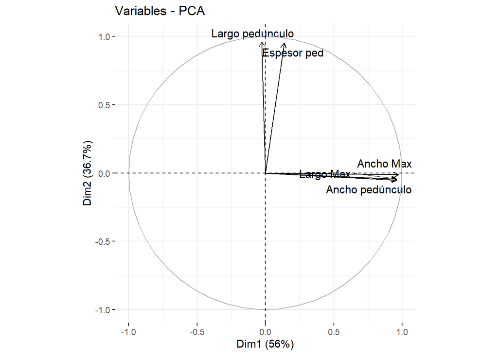

```r
fviz_pca_var(ACP,repel=TRUE)
```

### Se aprecia cómo existe un relación casi ortogonal entre el Largo pedunculo y Espesor ped con el Largo Max, Ancho pedúnculo y Ancho Max

### d) Construya un gráfico de ACP que permita visualizar la relación entre los grupos morfológicos (lanceolada, triangular, pedunculada) y los componentes extraídos. Comente en base a este gráfico qué caracterizaría a cada uno de los grupos

### Primero hacemos el biplot

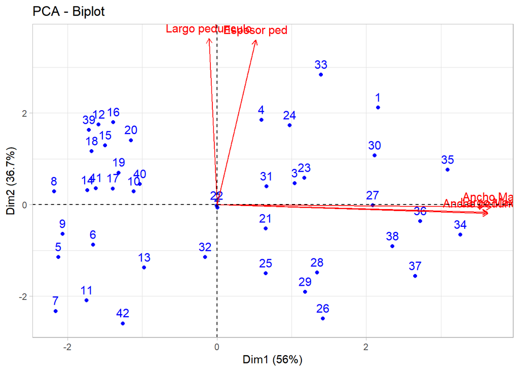

```r
fviz_pca(ACP, col.ind = "blue", col.var = "red") + theme_light()
```

### Luevo vemos el gráfico Biplot de ACP relacionado con los grupos morfológicos

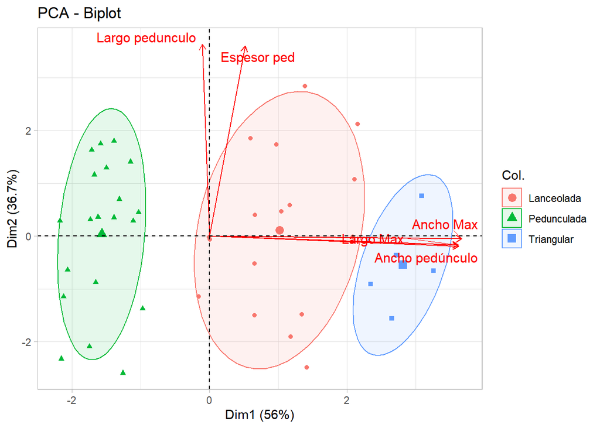

```r
fviz_pca(ACP, col.ind = base$Morfología, col.var = "red", label="var", repel = TRUE, addEllipses=TRUE, ellipse.level=0.75) + theme_light()
```

### Una forma de caracterizarlos es a traves de una estadística descriptiva de cada uno de los grupos morfológicos

```r
by( data=base[,2:6], INDICES=base$Morfología, FUN=summary )
```

```
base$Morfología: Lanceolada
   Largo Max       Ancho Max     Ancho pedúnculo Largo pedunculo
 Min.   :4.000   Min.   :2.200   Min.   :2.200   Min.   :1.0
 1st Qu.:4.200   1st Qu.:2.600   1st Qu.:2.500   1st Qu.:1.4
 Median :4.500   Median :2.800   Median :2.700   Median :1.6
 Mean   :4.524   Mean   :2.824   Mean   :2.747   Mean   :1.6
 3rd Qu.:4.800   3rd Qu.:3.100   3rd Qu.:3.000   3rd Qu.:1.8
 Max.   :5.100   Max.   :3.400   Max.   :3.400   Max.   :2.4
  Espesor ped
 Min.   :0.4400
 1st Qu.:0.6500
 Median :0.7800
 Mean   :0.7976
 3rd Qu.:1.0100
 Max.   :1.0900
------------------------------------------------------------
base$Morfología: Pedunculada
   Largo Max       Ancho Max     Ancho pedúnculo Largo pedunculo
 Min.   :2.300   Min.   :1.600   Min.   :1.000   Min.   :0.900
 1st Qu.:2.400   1st Qu.:1.775   1st Qu.:1.175   1st Qu.:1.275
 Median :2.550   Median :2.000   Median :1.250   Median :1.750
 Mean   :2.595   Mean   :1.960   Mean   :1.275   Mean   :1.575
 3rd Qu.:2.800   3rd Qu.:2.100   3rd Qu.:1.325   3rd Qu.:1.825
 Max.   :3.000   Max.   :2.300   Max.   :1.800   Max.   :2.000
  Espesor ped
 Min.   :0.4300
 1st Qu.:0.6650
 Median :0.7500
 Mean   :0.7585
 3rd Qu.:0.8975
 Max.   :1.0600
------------------------------------------------------------
base$Morfología: Triangular
   Largo Max      Ancho Max    Ancho pedúnculo Largo pedunculo  Espesor ped
 Min.   :6.00   Min.   :3.00   Min.   :2.70    Min.   :1.15    Min.   :0.600
 1st Qu.:6.45   1st Qu.:3.30   1st Qu.:3.15    1st Qu.:1.30    1st Qu.:0.620
 Median :6.45   Median :3.60   Median :3.30    Median :1.40    Median :0.780
 Mean   :6.72   Mean   :3.48   Mean   :3.21    Mean   :1.41    Mean   :0.748
 3rd Qu.:7.05   3rd Qu.:3.60   3rd Qu.:3.45    3rd Qu.:1.50    3rd Qu.:0.800
 Max.   :7.65   Max.   :3.90   Max.   :3.45    Max.   :1.70    Max.   :0.940
```

### Observamos que los mayores promedios de Largo Max, Ancho Max y Ancho pedúnculo, están en el grupo Triangular, lo que claramente se relaciona con el componente 1.

### Por otro lado, destacamos que dentro del Largo pedunculo y Espesor ped sus mayores promedios se encuentran en el grupo Lanceolada y Pedunculada, lo que claramente se relaciona con el segundo componente.

### Por su parte, el grupo Pedunculada, posee los menores promedios para Largo Max, Ancho Max y Ancho pedúnculo

### En resumen podemos observar que el ACP “ordena” las puntas de proyectil desde las de menor a las de mayor tamaño y forma.

### Podemos visualizarlos en graficos de boxplot de cada variable

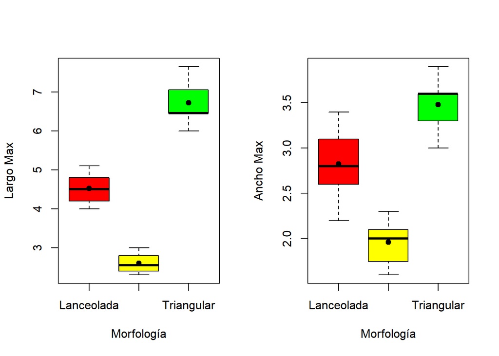

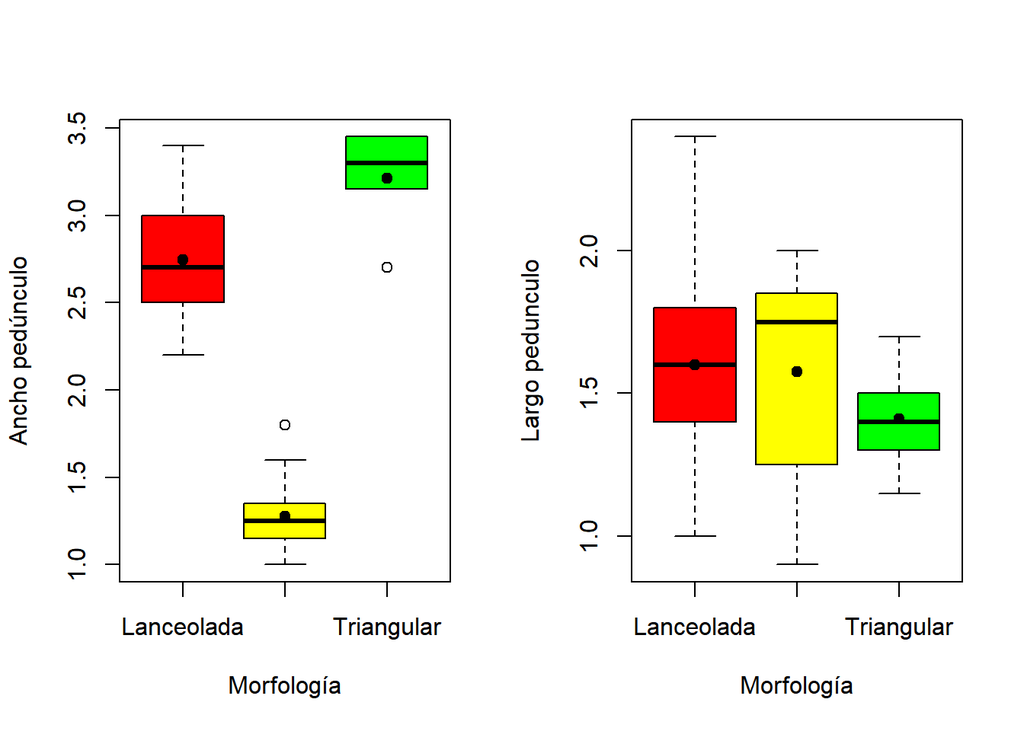

```r
par(mfrow=c(1,2))
for(i in 2:6){
  boxplot(unlist(base[,i])~base$Morfología, xlab = names(base[,1]), ylab=names(base[,i]), col = rainbow(ncol(base)) )
  points(by(unlist(base[,i]), INDICES=base$Morfología, FUN=mean ), col = 1, pch = 19)
}
```

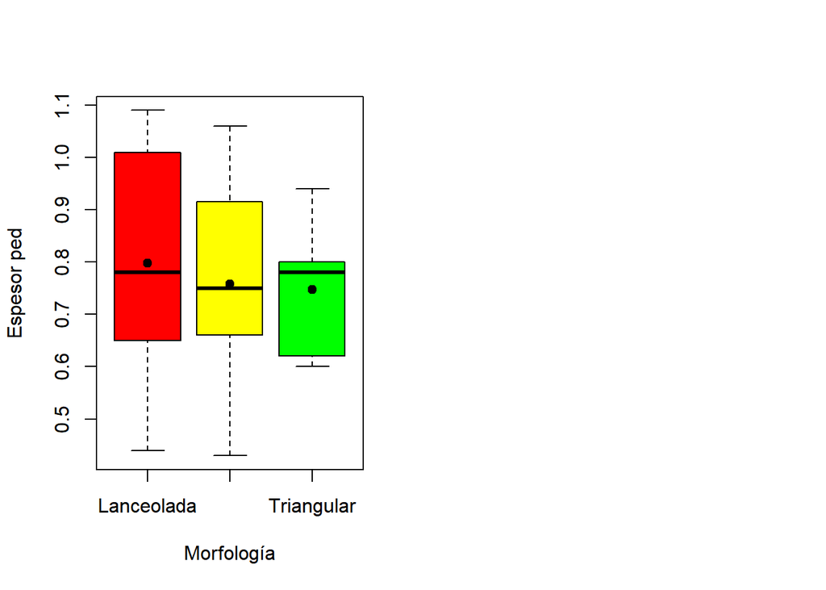

```r
par(mfrow=c(1,1))
```

### e) ¿Es posible relacionar los resultados del análisis de conglomerados con los del ACP? ¿De qué forma? Efectúe alguna gráfica que permita visualizar y analizar esta relación.

### Podemos visualizar ahora el gráfico Biplot de ACP relacionado con el cluster jerárquico

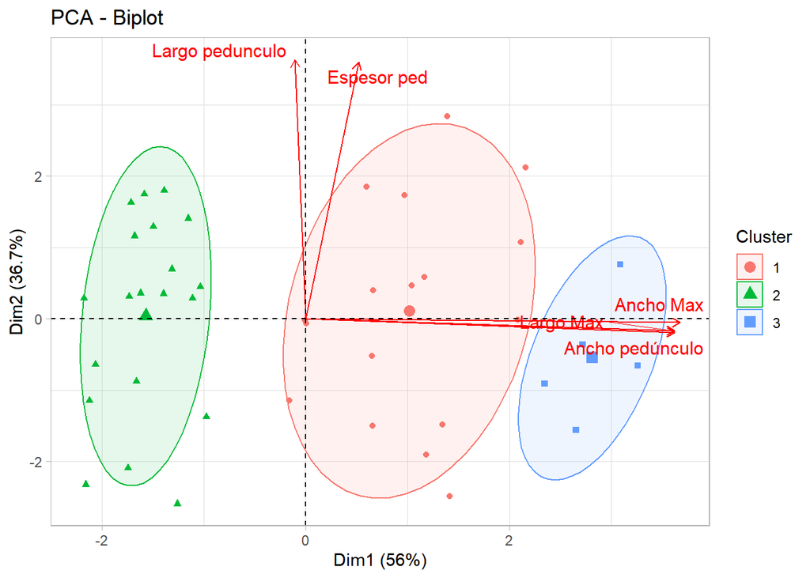

```r
fviz_pca(ACP, col.ind = df$clusterj, col.var = "red", label="var", repel = TRUE, addEllipses=TRUE, legend.title="Cluster",ellipse.level=0.75) + theme_light()
```

### Observamos que la disposición de cluster es idéntica a los grupos morfológicos

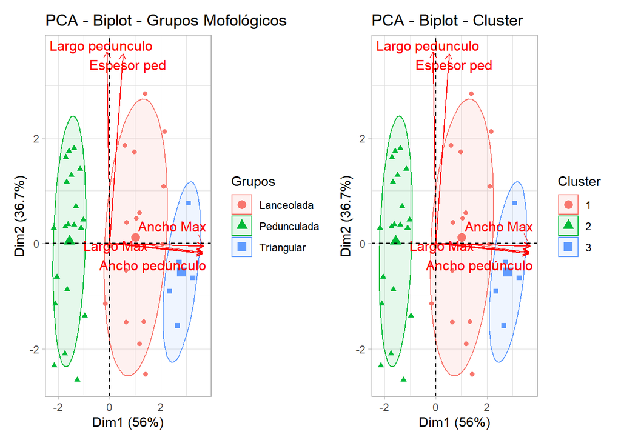

```r
a1 <- fviz_pca(ACP, col.ind = base$Morfología, col.var = "red", label="var", repel = TRUE, addEllipses=TRUE, legend.title="Grupos", ellipse.level=0.75, title = "PCA - Biplot - Grupos Mofológicos") + theme_light()
a2 <- fviz_pca(ACP, col.ind = df$clusterj, col.var = "red", label="var", repel = TRUE, addEllipses=TRUE, legend.title="Cluster", ellipse.level=0.75, title = "PCA - Biplot - Cluster") + theme_light()
a1 + a2
```

### Por tanto coincidimos que los cluster se han definido según su tipo morfológico.